# Investigating a Dataset

#### TMDb Movies

Today we will be analyzing the TMDb data set from Kaggle. This data set has almost 11,000 movie entries that include the movie's title, budget, revenue, ratings and many other columns with detialed information. We will assess the data, clean, format it and analyze it.

Questions to answer:

1. What are the most popular genre in the dataframe?
2. Do films with higher voting counts have a higher profit?;
3. What is the average runtime?
4. Is runtime associated with higher profits?;
5. Which movies generated the most/least profit?;

To Begin, we want import all of the packages and libraries we will be using for our data analysis.

```python
import numpy as np, pandas as pd, matplotlib.pyplot as plt, seaborn as sns
sns.set_style('whitegrid')
pd.options.display.float_format = '{:20,.2f}'.format

%matplotlib inline
```

The first function we will begin using is the Pandas .read_csv(), to load our dataset as $df$

```python
#read in the csv file
df= pd.read_csv('tmdb-movies.csv')
```

Let us take a sneak peek by using the .head()

```python
df.head() #to display the first five rows and some columns of the df
```

|  | id | imdb_id | popularity | budget | revenue | original_title | cast | homepage | director | tagline | ... | overview | runtime | genres | production_companies | release_date | vote_count | vote_average | release_year | budget_adj | revenue_adj |
| --- | --- | --- | --- | --- | --- | --- | --- | --- | --- | --- | --- | --- | --- | --- | --- | --- | --- | --- | --- | --- | --- |
| 0 | 135397 | tt0369610 | 32.99 | 150000000 | 1513528810 | Jurassic World | Chris Pratt\|Bryce Dallas Howard\|Irrfan Khan\|Vi... | http://www.jurassicworld.com/ | Colin Trevorrow | The park is open. | ... | Twenty-two years after the events of Jurassic ... | 124 | Action\|Adventure\|Science Fiction\|Thriller | Universal Studios\|Amblin Entertainment\|Legenda... | 6/9/15 | 5562 | 6.50 | 2015 | 137,999,939.28 | 1,392,445,892.52 |
| 1 | 76341 | tt1392190 | 28.42 | 150000000 | 378436354 | Mad Max: Fury Road | Tom Hardy\|Charlize Theron\|Hugh Keays-Byrne\|Nic... | http://www.madmaxmovie.com/ | George Miller | What a Lovely Day. | ... | An apocalyptic story set in the furthest reach... | 120 | Action\|Adventure\|Science Fiction\|Thriller | Village Roadshow Pictures\|Kennedy Miller Produ... | 5/13/15 | 6185 | 7.10 | 2015 | 137,999,939.28 | 348,161,292.49 |
| 2 | 262500 | tt2908446 | 13.11 | 110000000 | 295238201 | Insurgent | Shailene Woodley\|Theo James\|Kate Winslet\|Ansel... | http://www.thedivergentseries.movie/#insurgent | Robert Schwentke | One Choice Can Destroy You | ... | Beatrice Prior must confront her inner demons ... | 119 | Adventure\|Science Fiction\|Thriller | Summit Entertainment\|Mandeville Films\|Red Wago... | 3/18/15 | 2480 | 6.30 | 2015 | 101,199,955.47 | 271,619,025.41 |
| 3 | 140607 | tt2488496 | 11.17 | 200000000 | 2068178225 | Star Wars: The Force Awakens | Harrison Ford\|Mark Hamill\|Carrie Fisher\|Adam D... | http://www.starwars.com/films/star-wars-episod... | J.J. Abrams | Every generation has a story. | ... | Thirty years after defeating the Galactic Empi... | 136 | Action\|Adventure\|Science Fiction\|Fantasy | Lucasfilm\|Truenorth Productions\|Bad Robot | 12/15/15 | 5292 | 7.50 | 2015 | 183,999,919.04 | 1,902,723,129.80 |
| 4 | 168259 | tt2820852 | 9.34 | 190000000 | 1506249360 | Furious 7 | Vin Diesel\|Paul Walker\|Jason Statham\|Michelle ... | http://www.furious7.com/ | James Wan | Vengeance Hits Home | ... | Deckard Shaw seeks revenge against Dominic Tor... | 137 | Action\|Crime\|Thriller | Universal Pictures\|Original Film\|Media Rights ... | 4/1/15 | 2947 | 7.30 | 2015 | 174,799,923.09 | 1,385,748,801.47 |

5 rows × 21 columns

Let's also survey the value types for each columns, as well as their "non-null" values.

```python
df.info() # to get general information on the column data types, value counts, missing values, etc...
```

```
<class 'pandas.core.frame.DataFrame'>
RangeIndex: 10866 entries, 0 to 10865
Data columns (total 21 columns):
id                      10866 non-null int64
imdb_id                 10856 non-null object
popularity              10866 non-null float64
budget                  10866 non-null int64
revenue                 10866 non-null int64
original_title          10866 non-null object
cast                    10790 non-null object
homepage                2936 non-null object
director                10822 non-null object
tagline                 8042 non-null object
keywords                9373 non-null object
overview                10862 non-null object
runtime                 10866 non-null int64
genres                  10843 non-null object
production_companies    9836 non-null object
release_date            10866 non-null object
vote_count              10866 non-null int64
vote_average            10866 non-null float64
release_year            10866 non-null int64
budget_adj              10866 non-null float64
revenue_adj             10866 non-null float64
dtypes: float64(4), int64(6), object(11)
memory usage: 1.7+ MB
```

We can already see that there are some columns that have missing values. We'll deal with those in a moment.

To see how any rows and columns the dataset has:

```python
df.shape #displays rows and column counts
```

```
(10866, 21)
```

To get a list of all of the column names only:

```python
df.columns #to get a list of the column names
```

```
Index(['id', 'imdb_id', 'popularity', 'budget', 'revenue', 'original_title',
       'cast', 'homepage', 'director', 'tagline', 'keywords', 'overview',
       'runtime', 'genres', 'production_companies', 'release_date',
       'vote_count', 'vote_average', 'release_year', 'budget_adj',
       'revenue_adj'],
      dtype='object')
```

We can already see that some of the columns will not be so releveant for our analysis of this dataset. Getting these out of the way early on will make our exploration more effective.

The columns to be dropped are the following:

```python
#to drop the columns named
df.drop(columns=['imdb_id', 'homepage','overview', 'keywords','tagline','budget_adj', 'revenue_adj'], inplace=True)
```

These are the columns we will be working with for now:

```python
df.columns
```

```
Index(['id', 'popularity', 'budget', 'revenue', 'original_title', 'cast',
       'director', 'runtime', 'genres', 'production_companies', 'release_date',
       'vote_count', 'vote_average', 'release_year'],
      dtype='object')
```

Some general statistical summaries for the numerical data will also help us understand this dataset better.

```python
df.describe() # to get a statistical summary for the numeric values
```

|  | id | popularity | budget | revenue | runtime | vote_count | vote_average | release_year |
| --- | --- | --- | --- | --- | --- | --- | --- | --- |
| count | 10,866.00 | 10,866.00 | 10,866.00 | 10,866.00 | 10,866.00 | 10,866.00 | 10,866.00 | 10,866.00 |
| mean | 66,064.18 | 0.65 | 14,625,701.09 | 39,823,319.79 | 102.07 | 217.39 | 5.97 | 2,001.32 |
| std | 92,130.14 | 1.00 | 30,913,213.83 | 117,003,486.58 | 31.38 | 575.62 | 0.94 | 12.81 |
| min | 5.00 | 0.00 | 0.00 | 0.00 | 0.00 | 10.00 | 1.50 | 1,960.00 |
| 25% | 10,596.25 | 0.21 | 0.00 | 0.00 | 90.00 | 17.00 | 5.40 | 1,995.00 |
| 50% | 20,669.00 | 0.38 | 0.00 | 0.00 | 99.00 | 38.00 | 6.00 | 2,006.00 |
| 75% | 75,610.00 | 0.71 | 15,000,000.00 | 24,000,000.00 | 111.00 | 145.75 | 6.60 | 2,011.00 |
| max | 417,859.00 | 32.99 | 425,000,000.00 | 2,781,505,847.00 | 900.00 | 9,767.00 | 9.20 | 2,015.00 |

The 'vote_count' column is one that intrigues me. There seems to be great dispairity betweeen the min and max:

```python
df['vote_count'].describe()
```

```
count              10,866.00
mean                  217.39
std                   575.62
min                    10.00
25%                    17.00
50%                    38.00
75%                   145.75
max                 9,767.00
Name: vote_count, dtype: float64
```

Knowing the profits, or the difference between the revenue and the budget, will be interesting:

```python
df.insert(2,'profits', df['revenue']-df['budget']) # to generate a profits column (following the basic profits formula)
```

We have calculated the profits. We will use this information later.

Let's inspect the runtime column

```python
df.query('runtime == 0') # SQl-like query to narrow down by the values specified
```

|  | id | popularity | profits | budget | revenue | original_title | cast | director | runtime | genres | production_companies | release_date | vote_count | vote_average | release_year |
| --- | --- | --- | --- | --- | --- | --- | --- | --- | --- | --- | --- | --- | --- | --- | --- |
| 92 | 370687 | 1.88 | 0 | 0 | 0 | Mythica: The Necromancer | Melanie Stone\|Adam Johnson\|Kevin Sorbo\|Nicola ... | A. Todd Smith | 0 | Fantasy\|Action\|Adventure | Arrowstorm Entertainment\|Camera 40 Productions... | 12/19/15 | 11 | 5.40 | 2015 |
| 334 | 361931 | 0.36 | 0 | 0 | 0 | Ronaldo | Cristiano Ronaldo | Anthony Wonke | 0 | Documentary | On The Corner Films\|We Came, We Saw, We Conque... | 11/9/15 | 80 | 6.50 | 2015 |
| 410 | 339342 | 0.10 | 0 | 0 | 0 | Anarchy Parlor | Robert LaSardo\|Jordan James Smith\|Sara Fabel\|T... | Kenny Gage\|Devon Downs | 0 | Horror | NaN | 1/1/15 | 15 | 5.60 | 2015 |
| 445 | 353345 | 0.22 | 0 | 0 | 0 | The Exorcism of Molly Hartley | Sarah Lind\|Devon Sawa\|Gina Holden\|Peter MacNei... | Steven R. Monroe | 0 | Horror | WT Canada Productions | 10/9/15 | 52 | 5.00 | 2015 |
| 486 | 333653 | 0.18 | 0 | 0 | 0 | If There Be Thorns | Heather Graham\|Jason Lewis\|Rachael Carpani\|Mas... | Nancy Savoca | 0 | TV Movie\|Drama | A+E Studios\|Jane Startz Productions | 4/5/15 | 11 | 5.40 | 2015 |
| 595 | 341051 | 0.03 | 0 | 0 | 0 | Deep Dark | Sean McGrath\|Denise Poirier\|Anne Sorce\|Tabor H... | Michael Medaglia | 0 | Horror | NaN | 1/1/15 | 11 | 4.60 | 2015 |
| 616 | 325843 | 0.03 | 0 | 0 | 0 | The Outfield | Cameron Dallas\|Hamilton Nash Grier\|Olivia Stuc... | Michael Goldfine | 0 | Drama\|Comedy | NaN | 11/10/15 | 20 | 6.60 | 2015 |
| 1241 | 296370 | 0.14 | 0 | 0 | 0 | Dance-Off | Kathryn McCormick\|Shane Harper\|Finola Hughes\|C... | NaN | 0 | Romance\|Music\|Comedy | NaN | 1/1/14 | 18 | 5.70 | 2014 |
| 1289 | 286372 | 0.04 | -3250000 | 3250000 | 0 | Treehouse | J. Michael Trautmann\|Dana Melanie\|Daniel Fredr... | Michael G. Bartlett | 0 | Thriller\|Horror\|Mystery | Tiberius Film | 10/20/14 | 16 | 3.40 | 2014 |
| 1293 | 286256 | 0.04 | 0 | 0 | 0 | Tim Maia | Robson Nunes\|Babú Santana\|Alinne Moraes\|Cauã... | Mauro Lima | 0 | Documentary\|Drama\|Music | Globo Filmes | 10/30/14 | 14 | 6.00 | 2014 |
| 1849 | 18247 | 0.12 | 0 | 0 | 0 | Spectacular! | Nolan Gerard Funk\|Jesse Moss\|Britt Irvin\|Tammi... | Robert Iscove | 0 | Drama\|Music | NaN | 2/16/09 | 13 | 5.20 | 2009 |
| 2315 | 48373 | 0.17 | 0 | 0 | 0 | Listen to Your Heart | Alexia Rasmussen\|Kent Moran\|Cybill Shepherd\|Sh... | NaN | 0 | Drama\|Music\|Romance | NaN | 8/14/10 | 29 | 7.30 | 2010 |
| 2370 | 127717 | 0.08 | 0 | 0 | 0 | Freshman Father | Britt Irvin\|Merrilyn Gann\|Barbara Tyson\|Anthon... | Michael Scott | 0 | NaN | NaN | 6/5/10 | 12 | 5.80 | 2010 |
| 3329 | 20414 | 0.08 | 0 | 0 | 0 | Grande, grosso e Verdone | Carlo Verdone\|Claudia Gerini\|Eva Riccobono\|Vit... | Carlo Verdone | 0 | Family | Filmauro | 3/7/08 | 35 | 5.30 | 2008 |
| 3794 | 58253 | 0.18 | 0 | 0 | 0 | Toi, moi, les autres | Leïla Bekhti\|Benjamin Siksou\|Cécile Cassel\|C... | Audrey Estrougo | 0 | Music\|Romance | NaN | 2/22/11 | 17 | 5.20 | 2011 |
| 3857 | 289097 | 0.10 | 0 | 0 | 0 | Cell 213 | Bruce Greenwood\|Eric Balfour\|Michael Rooker\|De... | Stephen Kay | 0 | Horror | Access Motion Pictures | 6/10/11 | 13 | 5.20 | 2011 |
| 3884 | 105885 | 0.05 | 0 | 0 | 0 | eCupid | Houston Rhines\|Andy Anderson\|John Callahan\|Gal... | J.C. Calciano | 0 | Romance | NaN | 6/23/11 | 12 | 4.60 | 2011 |
| 4063 | 28004 | 0.37 | -6000000 | 6000000 | 0 | Madea's Family Reunion | Tyler Perry\|Blair Underwood\|Lynn Whitfield\|Bor... | Tyler Perry | 0 | Comedy | NaN | 1/25/02 | 49 | 5.90 | 2002 |
| 4138 | 44266 | 0.04 | 0 | 0 | 0 | A Time for Dancing | Larisa Oleynik\|Shiri Appleby\|Peter Coyote\|Patr... | Peter Gilbert | 0 | Drama\|Music | NaN | 9/6/02 | 14 | 7.50 | 2002 |
| 4829 | 110490 | 0.14 | 0 | 0 | 0 | Rags | Keke Palmer\|Avan Jogia\|Drake Bell\|Burkely Duff... | Bille Woodruff | 0 | TV Movie\|Comedy\|Drama | NaN | 5/28/12 | 24 | 5.70 | 2012 |
| 4944 | 158150 | 0.03 | 0 | 0 | 0 | How to Fall in Love | Brooke D'Orsay\|Eric Mabius\|Jody Thompson\|Gina ... | Mark Griffiths | 0 | Comedy\|Romance\|TV Movie | Annuit Coeptis Entertainment Inc.\|Annuit Coept... | 7/21/12 | 11 | 4.70 | 2012 |
| 5216 | 28003 | 0.07 | 0 | 0 | 0 | Madea's Class Reunion | Tyler Perry\|Chandra Currelley\|Cheryl Pepsii Ri... | Tyler Perry | 0 | Comedy\|Music | NaN | 6/25/03 | 12 | 6.90 | 2003 |
| 5695 | 224815 | 0.42 | 0 | 0 | 0 | Skinwalker Ranch | Steve Berg\|Kyle Davis\|Erin Cahill\|Jon Gries\|De... | Devin McGinn | 0 | Thriller\|Horror\|Science Fiction | DeepStudios | 10/30/13 | 27 | 4.30 | 2013 |
| 5920 | 248842 | 0.17 | 0 | 0 | 0 | The Food Guide to Love | Richard Coyle\|Leonor Watling\|Ginés García Mi... | Dominic Harari\|Teresa Pelegri | 0 | Romance\|Comedy | Haut et Court\|Parallel Film Productions\|Fox In... | 12/18/13 | 12 | 5.60 | 2013 |
| 5938 | 191562 | 0.15 | 0 | 0 | 0 | Go Goa Gone | Saif Ali Khan\|Anand Tiwari\|Vir Das\|Pooja Gupta | Krishna D.K.\|Raj Nidimoru | 0 | Comedy\|Horror | Eros International | 5/10/13 | 16 | 5.30 | 2013 |
| 5992 | 173847 | 0.10 | 0 | 0 | 0 | Amiche da morire | Claudia Gerini\|Cristiana Capotondi\|Sabrina Imp... | Giorgia Farina | 0 | Romance\|Crime\|Comedy | NaN | 3/7/13 | 30 | 5.50 | 2013 |
| 6040 | 202604 | 0.01 | 0 | 0 | 0 | The Vatican Exorcisms | Joe Marino | Joe Marino | 0 | Horror\|Documentary\|Mystery | NaN | 5/29/13 | 10 | 4.70 | 2013 |
| 6383 | 26985 | 0.37 | -2000000 | 2000000 | 0 | The 12 Dogs of Christmas | Jordan-Claire Green\|Tom Kemp\|Susan Wood\|Adam H... | Kieth Merrill | 0 | Drama\|Family | NaN | 11/1/05 | 11 | 4.70 | 2005 |
| 6552 | 13739 | 0.01 | 0 | 0 | 0 | Quatre étoiles | José Garcia\|Isabelle Carré\|Renée Le Calm\|Fr... | Christian Vincent | 0 | Comedy | NaN | 1/1/05 | 15 | 5.90 | 2005 |
| 6934 | 13713 | 0.07 | 0 | 0 | 0 | Jean-Philippe | Fabrice Luchini\|Johnny Hallyday\|Jackie Berroye... | Laurent Tuel | 0 | Comedy | Fidélité Productions\|StudioCanal\|TF1 Films P... | 4/5/06 | 26 | 5.60 | 2006 |
| 8874 | 46406 | 0.07 | 0 | 0 | 0 | Mission Kashmir | Sanjay Dutt\|Hrithik Roshan\|Preity Zinta\|Jackie... | Vidhu Vinod Chopra | 0 | Action\|Drama\|Foreign | NaN | 10/27/00 | 10 | 5.70 | 2000 |

Many of the films are 0 mins long? These need to go!

```python
df.isnull().sum(axis=0) #displays the number of null values on each column
```

```
id                         0
popularity                 0
profits                    0
budget                     0
revenue                    0
original_title             0
cast                      76
director                  44
runtime                    0
genres                    23
production_companies    1030
release_date               0
vote_count                 0
vote_average               0
release_year               0
dtype: int64
```

We also have some other rows with null values.

Let's drop the rows were there are no values and the duplicates:

```python
df.dropna(how='any', inplace= True) #to drop empty rows
```

```python
df.drop_duplicates(inplace= True) # drops duplicated values
```

```python
df.query('budget ==0').head()
```

|  | id | popularity | profits | budget | revenue | original_title | cast | director | runtime | genres | production_companies | release_date | vote_count | vote_average | release_year |
| --- | --- | --- | --- | --- | --- | --- | --- | --- | --- | --- | --- | --- | --- | --- | --- |
| 30 | 280996 | 3.93 | 29355203 | 0 | 29355203 | Mr. Holmes | Ian McKellen\|Milo Parker\|Laura Linney\|Hattie M... | Bill Condon | 103 | Mystery\|Drama | BBC Films\|See-Saw Films\|FilmNation Entertainme... | 6/19/15 | 425 | 6.40 | 2015 |
| 36 | 339527 | 3.36 | 22354572 | 0 | 22354572 | Solace | Abbie Cornish\|Jeffrey Dean Morgan\|Colin Farrel... | Afonso Poyart | 101 | Crime\|Drama\|Mystery | Eden Rock Media\|FilmNation Entertainment\|Flynn... | 9/3/15 | 474 | 6.20 | 2015 |
| 72 | 284289 | 2.27 | 45895 | 0 | 45895 | Beyond the Reach | Michael Douglas\|Jeremy Irvine\|Hanna Mangan Law... | Jean-Baptiste LÃ©onetti | 95 | Thriller | Furthur Films | 4/17/15 | 81 | 5.50 | 2015 |
| 74 | 347096 | 2.17 | 0 | 0 | 0 | Mythica: The Darkspore | Melanie Stone\|Kevin Sorbo\|Adam Johnson\|Jake St... | Anne K. Black | 108 | Action\|Adventure\|Fantasy | Arrowstorm Entertainment | 6/24/15 | 27 | 5.10 | 2015 |
| 75 | 308369 | 2.14 | 0 | 0 | 0 | Me and Earl and the Dying Girl | Thomas Mann\|RJ Cyler\|Olivia Cooke\|Connie Britt... | Alfonso Gomez-Rejon | 105 | Comedy\|Drama | Indian Paintbrush | 6/12/15 | 569 | 7.70 | 2015 |

We will replace the zeroes in these columns with "NaNs", then we'll drop them:

```python
# let's replace "not a number values", sometimes empty fields, with zeroes
df['budget'] = df['budget'].replace(0, np.NaN)
df['revenue'] = df['revenue'].replace(0, np.NaN)
df['runtime'] = df['runtime'].replace(0, np.NaN)
```

```python
df.query('budget == 0')
```

|  | id | popularity | profits | budget | revenue | original_title | cast | director | runtime | genres | production_companies | release_date | vote_count | vote_average | release_year |
| --- | --- | --- | --- | --- | --- | --- | --- | --- | --- | --- | --- | --- | --- | --- | --- |

```python
df.isnull().sum()
```

```
id                         0
popularity                 0
profits                    0
budget                  4751
revenue                 5022
original_title             0
cast                       0
director                   0
runtime                   13
genres                     0
production_companies       0
release_date               0
vote_count                 0
vote_average               0
release_year               0
dtype: int64
```

```python
df.dropna(subset=['revenue', 'budget', 'runtime','cast', 'director', 'genres'], how='any', inplace= True)
```

```python
df.isnull().sum()
```

```
id                      0
popularity              0
profits                 0
budget                  0
revenue                 0
original_title          0
cast                    0
director                0
runtime                 0
genres                  0
production_companies    0
release_date            0
vote_count              0
vote_average            0
release_year            0
dtype: int64
```

```python
df.describe()
```

|  | id | popularity | profits | budget | revenue | runtime | vote_count | vote_average | release_year |
| --- | --- | --- | --- | --- | --- | --- | --- | --- | --- |
| count | 3,805.00 | 3,805.00 | 3,805.00 | 3,805.00 | 3,805.00 | 3,805.00 | 3,805.00 | 3,805.00 | 3,805.00 |
| mean | 40,040.37 | 1.20 | 71,365,395.43 | 37,607,996.56 | 108,973,391.99 | 109.35 | 534.16 | 6.17 | 2,001.23 |
| std | 67,585.71 | 1.48 | 151,376,384.93 | 42,321,790.88 | 177,297,589.91 | 19.85 | 883.76 | 0.79 | 11.33 |
| min | 5.00 | 0.01 | -413,912,431.00 | 1.00 | 2.00 | 15.00 | 10.00 | 2.20 | 1,960.00 |
| 25% | 5,925.00 | 0.47 | -1,173,477.00 | 10,000,000.00 | 14,333,790.00 | 96.00 | 74.00 | 5.70 | 1,995.00 |
| 50% | 11,253.00 | 0.81 | 20,474,340.00 | 25,000,000.00 | 46,216,641.00 | 106.00 | 209.00 | 6.20 | 2,004.00 |
| 75% | 38,579.00 | 1.39 | 83,473,333.00 | 50,000,000.00 | 126,069,509.00 | 119.00 | 584.00 | 6.70 | 2,010.00 |
| max | 417,859.00 | 32.99 | 2,544,505,847.00 | 425,000,000.00 | 2,781,505,847.00 | 338.00 | 9,767.00 | 8.40 | 2,015.00 |

We are all done with cleaning for now. Let's now proceed to explore this data!

Let's sort the data by the release year:

```python
cleaned_df = df.groupby('release_year').mean()
```

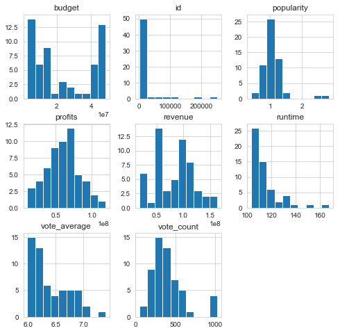

```python
cleaned_df.hist(figsize= (8,8));
```

Looks like we are ready to dive into it!

## Exploratory Data Analysis

### What are the most popular genre in the dataframe?

```python
df.genres.head()
```

```
0    Action|Adventure|Science Fiction|Thriller
1    Action|Adventure|Science Fiction|Thriller
2           Adventure|Science Fiction|Thriller
3     Action|Adventure|Science Fiction|Fantasy
4                        Action|Crime|Thriller
Name: genres, dtype: object
```

To answer the first question, we need to do some further data wrangling, since the 'Genres' column is dividing the categories using "|". For us to be able to use this, we need to separate them.

```python
imdb_genres = df.copy()
imdb_genres.drop(['original_title', 'cast', 'director', 'runtime', 'release_date', 'production_companies', 'vote_count', 'vote_average'], axis=1, inplace=True)
imdb_genres.head(1)
```

|  | id | popularity | profits | budget | revenue | genres | release_year |
| --- | --- | --- | --- | --- | --- | --- | --- |
| 0 | 135397 | 32.99 | 1363528810 | 150,000,000.00 | 1,513,528,810.00 | Action\|Adventure\|Science Fiction\|Thriller | 2015 |

```python
imdb_genres.dropna(axis=0, how='any', inplace=True)
```

```python
genre = imdb_genres.loc[:, ['id', 'genres']]
genre.head(5)
```

|  | id | genres |
| --- | --- | --- |
| 0 | 135397 | Action\|Adventure\|Science Fiction\|Thriller |
| 1 | 76341 | Action\|Adventure\|Science Fiction\|Thriller |
| 2 | 262500 | Adventure\|Science Fiction\|Thriller |
| 3 | 140607 | Action\|Adventure\|Science Fiction\|Fantasy |
| 4 | 168259 | Action\|Crime\|Thriller |

```python
# to separate the genres and enter them into a list for each row
genres_list = df['genres'].str.split('|').tolist()
genres_list[:2]
```

```
[['Action', 'Adventure', 'Science Fiction', 'Thriller'],
 ['Action', 'Adventure', 'Science Fiction', 'Thriller']]
```

```python
# this for loop will iterate for each element in the genres list created above
# confirm each element is a list datatype
# if the isinstance result is false, it will convert the given element to a list
for i in range(len(genres_list)):
    if not isinstance(genres_list[i], list):
        genres_list[i] = [genres_list[i]]
```

```python
# Let's use the "id" for our index and pivot the data
listed_genres = pd.DataFrame(genres_list, index=genre['id']).stack()
```

```python
listed_genres = listed_genres.reset_index()
```

```python
listed_genres = listed_genres.loc[:, ['id', 0]]
```

```python
listed_genres.columns = ['id', 'genre']
```

```python
# Let's merge these two dataframes for the rest of our analysis
#each genre will have its own row
paired_df = pd.merge(imdb_genres, listed_genres, on='id', how='left')
paired_df.drop(['genres', 'id'], axis=1, inplace=True)
```

```python
paired_df.head()
```

|  | popularity | profits | budget | revenue | release_year | genre |
| --- | --- | --- | --- | --- | --- | --- |
| 0 | 32.99 | 1363528810 | 150,000,000.00 | 1,513,528,810.00 | 2015 | Action |
| 1 | 32.99 | 1363528810 | 150,000,000.00 | 1,513,528,810.00 | 2015 | Adventure |
| 2 | 32.99 | 1363528810 | 150,000,000.00 | 1,513,528,810.00 | 2015 | Science Fiction |
| 3 | 32.99 | 1363528810 | 150,000,000.00 | 1,513,528,810.00 | 2015 | Thriller |
| 4 | 28.42 | 228436354 | 150,000,000.00 | 378,436,354.00 | 2015 | Action |

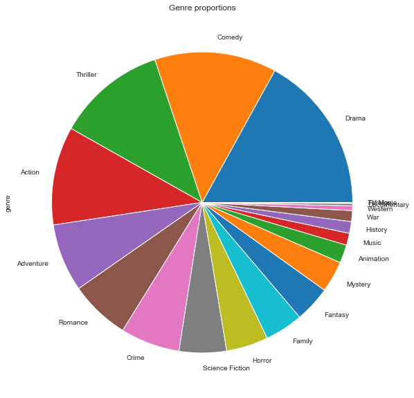

```python
# now we can generate a pie chart for the genres
paired_df['genre'].value_counts().plot(kind='pie', figsize=(10, 10), title="Genre proportions");
```

The predominant genres are "drama", "comedy", "thiller" and "action". Some of the other genres might be subcategories of these as well. This horizontal bar chart allows us to visualize this data better:

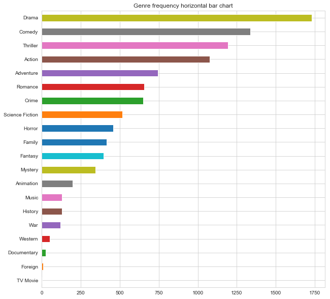

```python
# let's explore a horizontal bar chart of the genres
paired_df['genre'].value_counts(ascending=True).plot(kind='barh', figsize=(10,10), title="Genre frequency horizontal bar chart");
```

Let's survey the data from above:

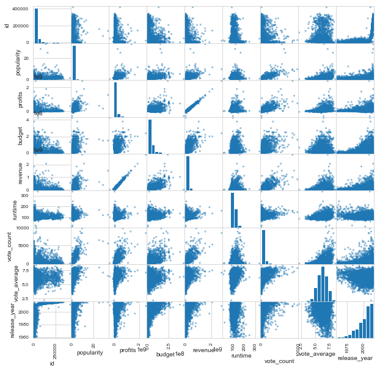

```python
#eagle's eye view of the scatter plots and histograms
pd.plotting.scatter_matrix(df, figsize=(10,10));
```

### Do films with higher voting counts have a higher profit?

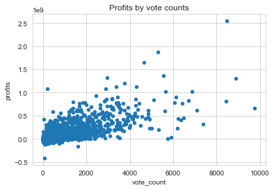

```python
df.plot(x='vote_count', y='profits', kind='scatter', title="Profits by vote counts");
```

The correlation is not super strong, but it is sufficient for us to see something here. Of course, we are not infering that more vote "cause" higher profits. However, this might be the case. The outliers in this here should still be considered. It makes sense for the most successful movies to have both the highest voting counts and profits.

Now let's analyze runtime

### What is the average runtime?

```python
df.runtime.describe()
```

```
count               3,805.00
mean                  109.35
std                    19.85
min                    15.00
25%                    96.00
50%                   106.00
75%                   119.00
max                   338.00
Name: runtime, dtype: float64
```

Our average film is one hour and 49 minutes long. Sounds about right!

The median is very similar at one hour and 46 minutes.

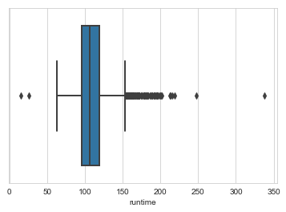

```python
#Let's use a box plot to see a visual of the movies' runtime
plt.figure()
sns.boxplot(df['runtime'], linewidth = 2)
plt.show()
```

Who is that lonely outlier up there?

```python
df.loc[df['runtime'].idxmax()]
```

```
id                                                                  43434
popularity                                                           0.53
profits                                                         -17128721
budget                                                      18,000,000.00
revenue                                                        871,279.00
original_title                                                     Carlos
cast                    Edgar RamÃrez|Alexander Scheer|Fadi Abi Samra...
director                                                  Olivier Assayas
runtime                                                            338.00
genres                                       Crime|Drama|Thriller|History
production_companies    Egoli Tossell Film AG|Canal+|Arte France|Films...
release_date                                                      5/19/10
vote_count                                                             35
vote_average                                                         6.20
release_year                                                         2010
Name: 2107, dtype: object
```

### Is runtime associated with higher profits?

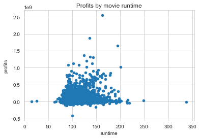

```python
df.plot(x='runtime', y='profits', kind='scatter', title="Profits by movie runtime");
```

It is not so clear in this visual. Do the stats give us a little more insight?

It seems like movies with runtime of 120 mins or higher average higher profits:

```python
df[['profits', 'runtime']].describe()
```

|  | profits | runtime |
| --- | --- | --- |
| count | 3,805.00 | 3,805.00 |
| mean | 71,365,395.43 | 109.35 |
| std | 151,376,384.93 | 19.85 |
| min | -413,912,431.00 | 15.00 |
| 25% | -1,173,477.00 | 96.00 |
| 50% | 20,474,340.00 | 106.00 |
| 75% | 83,473,333.00 | 119.00 |
| max | 2,544,505,847.00 | 338.00 |

```python
df[['profits', 'runtime']].query('runtime >= 120').describe()
```

|  | profits | runtime |
| --- | --- | --- |
| count | 938.00 | 938.00 |
| mean | 128,150,975.69 | 136.06 |
| std | 229,633,371.81 | 18.16 |
| min | -165,710,090.00 | 120.00 |
| 25% | 4,633,118.50 | 124.00 |
| 50% | 46,211,429.00 | 131.00 |
| 75% | 150,956,436.75 | 141.00 |
| max | 2,544,505,847.00 | 338.00 |

This doesn't mean there is a direct correlation between the two.

```python
df[['profits', 'runtime']].query('runtime >= 249').describe()
```

|  | profits | runtime |
| --- | --- | --- |
| count | 1.00 | 1.00 |
| mean | -17,128,721.00 | 338.00 |
| std | nan | nan |
| min | -17,128,721.00 | 338.00 |
| 25% | -17,128,721.00 | 338.00 |
| 50% | -17,128,721.00 | 338.00 |
| 75% | -17,128,721.00 | 338.00 |
| max | -17,128,721.00 | 338.00 |

### What about profit ratings?

Let's see which movie was the most profitable!

```python
df.loc[df['profits'].idxmax()]
```

```
id                                                                  19995
popularity                                                           9.43
profits                                                        2544505847
budget                                                     237,000,000.00
revenue                                                  2,781,505,847.00
original_title                                                     Avatar
cast                    Sam Worthington|Zoe Saldana|Sigourney Weaver|S...
director                                                    James Cameron
runtime                                                            162.00
genres                           Action|Adventure|Fantasy|Science Fiction
production_companies    Ingenious Film Partners|Twentieth Century Fox ...
release_date                                                     12/10/09
vote_count                                                           8458
vote_average                                                         7.10
release_year                                                         2009
Name: 1386, dtype: object
```

Looks like "Avatar" is the winner!

We can do the same thing for the worst movie (financially speaking)

```python
df.loc[df['profits'].idxmin()]
```

```
id                                                                  46528
popularity                                                           0.25
profits                                                        -413912431
budget                                                     425,000,000.00
revenue                                                     11,087,569.00
original_title                                          The Warrior's Way
cast                    Kate Bosworth|Jang Dong-gun|Geoffrey Rush|Dann...
director                                                       Sngmoo Lee
runtime                                                            100.00
genres                          Adventure|Fantasy|Action|Western|Thriller
production_companies                             Boram Entertainment Inc.
release_date                                                      12/2/10
vote_count                                                             74
vote_average                                                         6.40
release_year                                                         2010
Name: 2244, dtype: object
```

"The Warrior's Way" generated almost $414 million in losses! This movie is 62 minutes shorter than "Avatar" and its primary genre is not in the top 4.

## Conclusions

Analysing this data set was very instructive. I was able to apply the whole data analysis process to the data set. Seeing how we take a table full of names and numbers and transform it to someting everyone can digest produces a very rewarding feeling. The data wrangling process was very challenging for me. However, the most difficult step is to make visualizations that convey a story.

Limitations

Our analysis was very well hindered by some limitations. Some of these were within our reach to overcome (e.g., by doing external research), others were completely outside of our control and the scope of this project.

- One limitation we encountered was the number of missing and null values we had in the original dataset. Some of these were insignificant like "cast" and "homepage", others were more serious like have a movie's runtime be "0". There were also "0" values for important metrics like budget and revenue.
- Another limitation was that the dataset was packed with outliers, which we delath with to an extent, but still couldn't get completely rid of them. How can we determine who's an outlier or not in this dataset. This queston could be answer, but lies outside of the scope of this analysis.
- Another limitation was encountered when analyzing the genres. Most movies fall inside of multiple genre categories. Other genres could be considered subcategorical as well (i.e., "dramatic thillers", "action crime", "dramatic comedies", etc...)